# Factores influyentes para el desarrollo de la educación

# Factores influyentes para el desarrollo de la educación en Chile

Matilda Raccagni y Rodrigo Huerta

Analisis de datos Multinivel 2025

# Introducción

- **Problematización:** La educación es uno de los pilares fundamentales del desarrollo individual y colectivo, en la sociedad chilena actual, el acceso y logro educativo son procesos muy influenciados por factores estructurales e individuales
- **Variables a utilizar:** nivel educacional (dependiente), nivel educativo de los padres, etnicidad, conectividad digital y capacidad para concentrarse.

# ¿En qué grado inciden los factores individuales y estructurales en el nivel educativo máximo alcanzado por las personas en Chile?

### **Hipótesis – Nivel 1**

**H1**: La pertenencia a pueblos originarios se asocia negativamente con el nivel educacional.

**H2**: La dificultad para concentrarse tiene un efecto negativo sobre el nivel educacional.

### **Hipótesis – Nivel 2**

**H3**: Mayor conectividad comunal se asocia positivamente con el nivel educacional.

**H4**: Mayor educación promedio de los padres en la comuna se asocia positivamente con el nivel educacional.

**H5**: El efecto de la pertenencia a un pueblo indígena sobre el nivel educacional varía por la comuna de residencia.

### **Hipótesis – Interacción entre niveles**

**H6**: En comunas con mayor educación parental, el efecto negativo de ser indígena es menor.

# Metodología

- **Base de datos**: Encuesta CASEN 2022
- Diseño probabilístico, representatividad nacional
- **Submuestra**: 51.686 personas de 20+ años en 335 comunas

Para el análisis utilizamos la metodología multinivel, ya que según la literatura revisada, los factores de nivel dos inciden en nuestra variable dependiente.

## Tablas de descriptivos variables nivel 1 y 2

Las variables que vamos a utilizar son las siguientes

Descriptivos generales de variables nivel 1

|  | n | mean | sd | median | min | max | range |
| --- | --- | --- | --- | --- | --- | --- | --- |
| nvl_educ | 51686 | 3.76 | 1.86 | 4 | 0 | 8 | 8 |
| pueblo_indigena | 51686 | 0.13 | 0.34 | 0 | 0 | 1 | 1 |
| dificultad_conc | 51686 | 0.17 | 0.43 | 0 | 0 | 3 | 3 |

Descriptivos generales de variables de nivel 2

|  | n | mean | sd | median | min | max | range |
| --- | --- | --- | --- | --- | --- | --- | --- |
| mean_educ_padres | 335 | 2.03 | 0.32 | 1.99 | 1.37 | 3.48 | 2.12 |
| mean_conectividad | 335 | 1.81 | 0.55 | 1.73 | 0.70 | 3.39 | 2.69 |
| N_comunas | 335 | 154.29 | 222.58 | 78.00 | 6.00 | 1805.00 | 1799.00 |

# Centrado y casos influyentes

- Centramos ambas variables de nivel 2 a la gran media para lograr una mejor consistencia de los resultados.
- No detectamos casos influyentes

# Modelos

# Modelo Nulo

El modelo nulo se representa como

$$\text{nvl_educ}_{ij} = \gamma_{00} + u_{0j} + r_{ij}$$

# Modelo con predictores de nivel 1

$$\text{nvl_educ}_{ij} = \gamma_{00} + \gamma_{01} \text{pueblo_indígena}_{ij} + \gamma_{02} \text{dificultad_conc}_{ij}
+ u_{0j} + r_{ij}$$

# Modelos con predictores de nivel 2

$$\text{nvl_educ}_{ij} = \gamma_{00} + \gamma_{01} \text{mean_educ_padres_gmc}_{ij} + \gamma_{02} \text{mean_conectividad_gmc}_{ij}
+ u_{0j} + r_{ij}$$

# Modelos con predictores de nivel 1 y 2

$$\text{nvl_educ}_{ij} = \gamma_{00} + \gamma_{01} \text{pueblo_indígena}_{ij} + \gamma_{02} \text{dificultad_conc}_{ij} + \gamma_{03} \text{mean_educ_padres_gmc}_{ij} + \gamma_{04} \text{mean_conectividad_gmc}_{ij}
+ u_{0j} + r_{ij}$$

# Modelo con pendiente aleatoria

$$\text{nvl_educ}_{ij} = \gamma_{00} + \gamma_{01} \text{pueblo_indígena}_{ij} + \gamma_{02} \text{dificultad_conc}_{ij} + \gamma_{03} \text{mean_educ_padres_gmc}_{ij} + \gamma_{04} \text{mean_conectividad_gmc}_{ij}
+ u_{0j} + u_{1j} \text {pueblo_indigena}+ r_{ij}$$

# Modelo con interacción entre niveles

$$\text{nvl_educ}_{ij} = \gamma_{00} + \gamma_{01} \text{pueblo_indígena}_{ij} + \gamma_{02} \text{dificultad_conc}_{ij} + \gamma_{03} \text{mean_educ_padres_gmc}_{ij} + \gamma_{04} \text{mean_conectividad_gmc}_{ij} + \gamma_{05} \text{pueblo_indigena*mean_educ_padres_gmc}
+ u_{0j} + u_{1j} \text {pueblo_indigena}+ r_{ij}$$

# Resultados

# Gráfico Bivariado

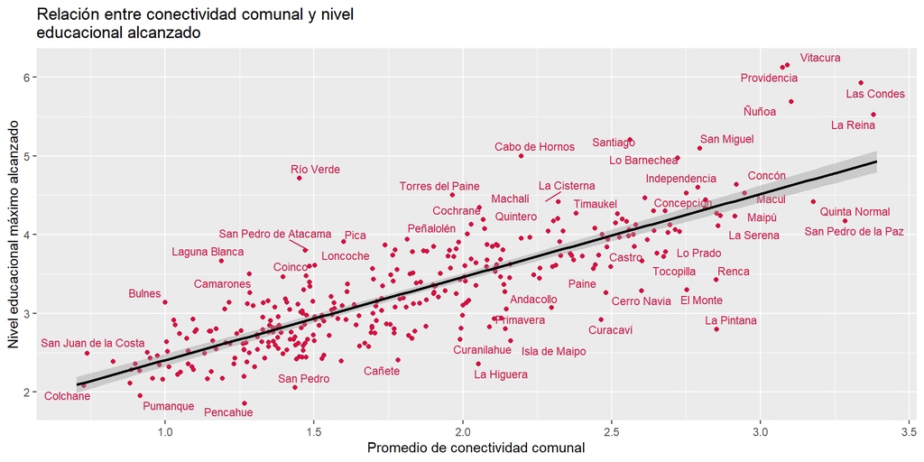

# Resultados

Comparación de modelos

|  | Modelo Nulo |  | Modelo con predictores de nivel 1 |  | Modelo con predictores de nivel 2 |  | Modelo con predictores de nivel 1 y 2 |  | Modelo con pendiente aleatoria |  | Modelo con interacción entre niveles |  |
| --- | --- | --- | --- | --- | --- | --- | --- | --- | --- | --- | --- | --- |
| Predictors | Estimates | p | Estimates | p | Estimates | p | Estimates | p | Estimates | p | Estimates | p |
| (Intercepto) | 3.27 | **<0.001** | 3.46 | **<0.001** | 3.74 | **<0.001** | 3.91 | **<0.001** | 3.90 | **<0.001** | 3.91 | **<0.001** |
| Pertenencia a pueblo indígena |  |  | -0.36 | **<0.001** |  |  | -0.32 | **<0.001** | -0.25 | **<0.001** | -0.26 | **<0.001** |
| Dificultad para concentrarse |  |  | -0.75 | **<0.001** |  |  | -0.75 | **<0.001** | -0.75 | **<0.001** | -0.75 | **<0.001** |
| Promedio nivel educativo de los padres (centrado) |  |  |  |  | 0.24 | **<0.001** | 0.22 | **<0.001** | 0.21 | **<0.001** | 0.22 | **<0.001** |
| Promedio conectividad (centrado) |  |  |  |  | 1.82 | **<0.001** | 1.77 | **<0.001** | 1.77 | **<0.001** | 1.78 | **<0.001** |
| Interacción (pueblo_indigena:mean_educ_padres) |  |  |  |  |  |  |  |  |  |  | -0.07 | 0.466 |
| Random Effects |  |  |  |  |  |  |  |  |  |  |  |  |
| σ<sup>2</sup> | 2.93 |  | 2.81 |  | 2.93 |  | 2.81 |  | 2.80 |  | 2.80 |  |
| τ<sub>00</sub> | 0.48 <sub>comuna_factor</sub> |  | 0.45 <sub>comuna_factor</sub> |  | 0.01 <sub>comuna_factor</sub> |  | 0.01 <sub>comuna_factor</sub> |  | 0.02 <sub>comuna_factor</sub> |  | 0.02 <sub>comuna_factor</sub> |  |
| τ<sub>11</sub> |  |  |  |  |  |  |  |  | 0.07 <sub>comuna_factor.pueblo_indigena</sub> |  | 0.07 <sub>comuna_factor.pueblo_indigena</sub> |  |
| ρ<sub>01</sub> |  |  |  |  |  |  |  |  | -0.67 <sub>comuna_factor</sub> |  | -0.67 <sub>comuna_factor</sub> |  |
| ICC | 0.14 |  | 0.14 |  | 0.00 |  | 0.01 |  | 0.01 |  | 0.01 |  |
| N | 335 <sub>comuna_factor</sub> |  | 335 <sub>comuna_factor</sub> |  | 335 <sub>comuna_factor</sub> |  | 335 <sub>comuna_factor</sub> |  | 335 <sub>comuna_factor</sub> |  | 335 <sub>comuna_factor</sub> |  |
| Observations | 51686 |  | 51686 |  | 51686 |  | 51686 |  | 51686 |  | 51686 |  |
| Marginal R<sup>2</sup> / Conditional R<sup>2</sup> | 0.000 / 0.142 |  | 0.036 / 0.168 |  | 0.151 / 0.154 |  | 0.184 / 0.188 |  | 0.181 / 0.188 |  | 0.182 / 0.189 |  |

# Test de Devianza

Comparación de modelos con test ANOVA

|  | npar | AIC | BIC | logLik | deviance | Chisq | Df | Pr(>Chisq) |
| --- | --- | --- | --- | --- | --- | --- | --- | --- |
| resultados_3 | 7 | 200284.7 | 200346.7 | -100135.3 | 200270.7 | NA | NA | NA |
| reg_al1 | 9 | 200242.3 | 200322.0 | -100112.2 | 200224.3 | 46.34181 | 2 | 0 |

# Gráfico de pendiente aleatoria (pueblo_indigena)

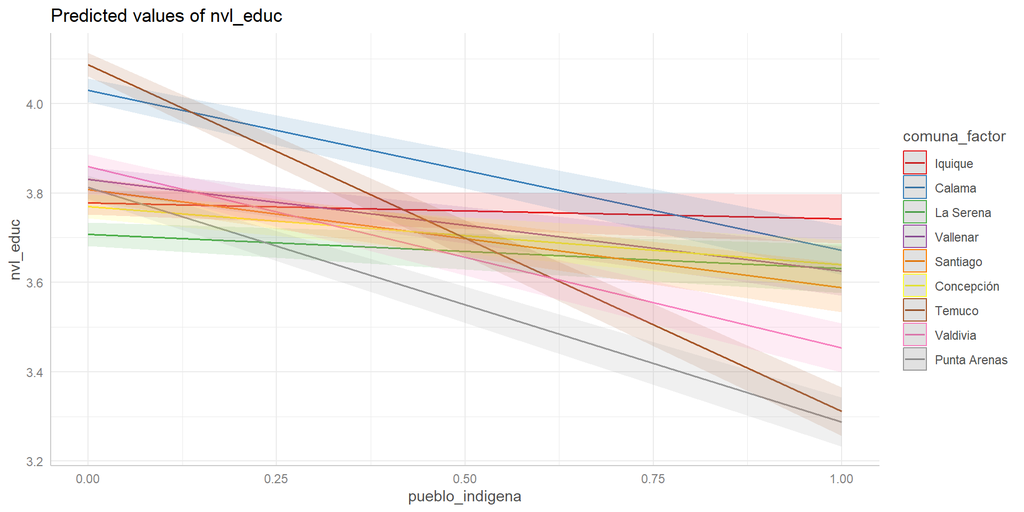

# Interacción entre niveles

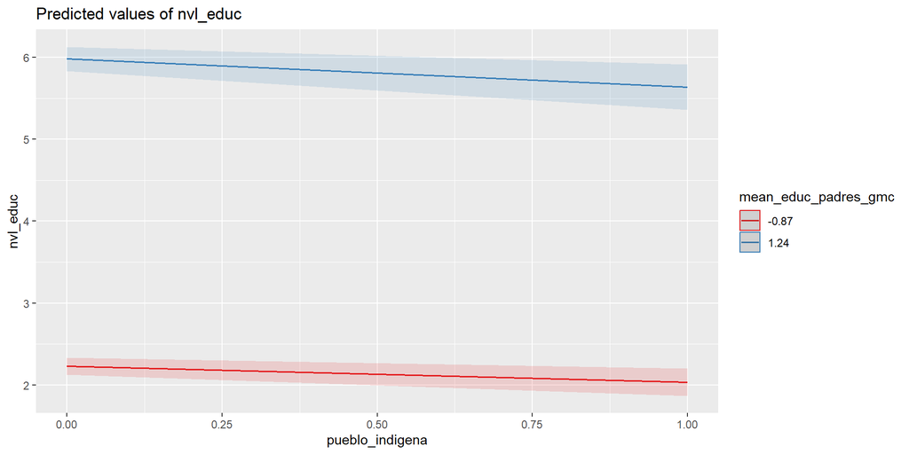

# Conclusiones

- Se confirma incidencia de factores individuales y estructurales
- Variables comunales tienen **efectos importantes**
- Interacción propuesta no se encontró significativa
- Efecto de la conectividad

# Bibliografía

- Bourdieu, P., & Passeron, J.-C. (1990). *La reproducción. Elementos para una teoría del sistema de enseñanza*. Laia.
- Jiménez, J. M., & Fernández, M. A. (2022). Problemas de concentración que afectan el rendimiento académico: Estudio de caso. *Latinoamérica. Revista de Estudios Educativos*, 52(1). https://latam.redilat.org/index.php/lt/article/view/3246
- López, J., & Escobar, A. (2008). Ser indígena en la educación superior: ¿Desventajas reales o percibidas? *Estudios Sociológicos*, 26(78), 713–736. https://www.scielo.org.mx/scielo.php?pid=S0185-27602008000400003&script=sci_arttext
- Mejía, D. A., & Mejía, M. T. (2023). La influencia de los padres en el rendimiento académico de los niños. *ResearchGate*. [https://www.researchgate.net/publication/391068651_La_influencia_de_los_padres_en_el_rendimiento_academico_de_los_ninosThe_influence_of_parents_on_children’s_academic_achievement](https://www.researchgate.net/publication/391068651_La_influencia_de_los_padres_en_el_rendimiento_academico_de_los_ninosThe_influence_of_parents_on_children's_academic_achievement)
- Rodríguez, F., Pérez, M., & Arévalo, J. (2021). Análisis sobre la educación virtual: impactos en el proceso formativo. *Revista Conrado*, 17(83). https://www.redalyc.org/journal/280/28073811035/html/
- Mide UC. (2020). *Indicadores de desarrollo comunal y escolar (IDCE): Desigualdades territoriales en la educación chilena.* Pontificia Universidad Católica de Chile. Recuperado de https://mideuc.cl